# Modelo del tipo ARIMA

Autor: Luis Fernando Apáez Álvarez

## Análisis descriptivo de los datos

Comenzamos por cargar y ver la serie de tiempo:

```r
ts <- tsdl[[91]]

# veamos un poco de informacion sobre dicha serie
attributes(ts)
```

```
## $tsp
## [1] 1981.000 1990.997  365.000
##
## $class
## [1] "ts"
##
## $source
## [1] "Australian Bureau of Meteorology"
##
## $description
## [1] "Daily maximum temperatures in Melbourne, Australia, 1981-1990"
##
## $subject
## [1] "Meteorology"
```

Gráficamente vemos la serie de tiempo

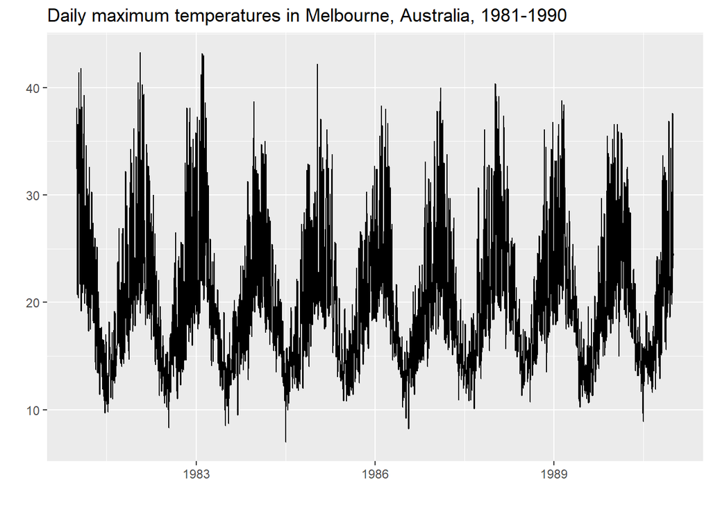

```r
autoplot(ts, main = "Daily maximum temperatures in Melbourne, Australia, 1981-1990")
```

En primera instancia, tenemos que la tendencia y la varianza parecen ser contantes pues no se aprecia un crecimiento tan grande en la dispersión de los datos.

En realidad, podemos notar que tenemos una tendencia aditiva pues los datos se comportan de una manera lineal. Por último, se puede observar que tiene ciclo estacional con periocidad de cada 365 días, lo cual podemos corroborar con los gráficos `acf` y `pacf`:

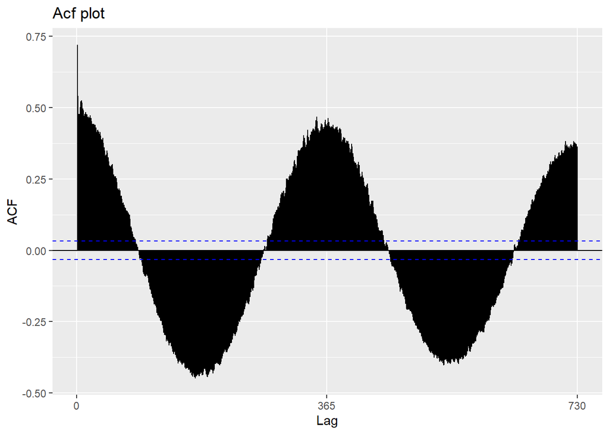

```r
ggAcf(ts, main="Acf plot")
```

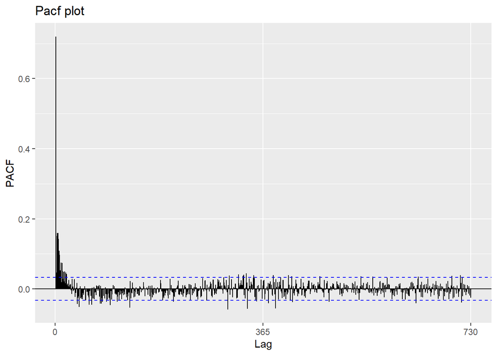

```r
ggPacf(ts, main="Pacf plot")
```

Continuamos observando que la serie de tiempo no tiene datos faltantes:

```r
# Suma de los datos faltantes en la serie de tiempo
sum(is.na(ts))
```

```
## [1] 0
```

De tal modo, no será necesario realizar imputaciones.

## Descomposición clásica

De acuerdo con los diferentes opciones para la descomposición clásica de la serie de tiempo, optamos por utilizar un modelo de regresión para obtener la tendencia y/o ciclos estacionales que pueda tener la serie con la que estamos trabajando.

Como se dijo en el análisis descriptivo, nos parece que la tendencia se comporta de manera lineal, sin embargo no estamos completamente seguros. Por lo anterior, podemos ajustar en el modelo de regresión lineal un cierto comportamiento polinomial, esto es:

```r
t <- time(ts)-1981
M <- factor(cycle(ts))

t2 <- t^2
t3 <- t^3
t4 <- t^4
t5 <- t^5
t6 <- t^6
t7 <- t^7
t8 <- t^8
t9 <- t^9


# ajuste del modelo
reg <- lm( ts ~ 0 + t + t2+ t3+ t4+ t5 + t6 + t7 + t8 + t9 + M , na.action=NULL)

# analisis de varianza
anova(reg)
```

```
## Analysis of Variance Table
##
## Response: ts
##             Df  Sum Sq Mean Sq   F value    Pr(>F)
## t            1 1088616 1088616 59315.431 < 2.2e-16 ***
## t2           1  192907  192907 10510.913 < 2.2e-16 ***
## t3           1   70096   70096  3819.299 < 2.2e-16 ***
## t4           1   36693   36693  1999.286 < 2.2e-16 ***
## t5           1   19333   19333  1053.380 < 2.2e-16 ***
## t6           1    7838    7838   427.047 < 2.2e-16 ***
## t7           1    9833    9833   535.790 < 2.2e-16 ***
## t8           1    1863    1863   101.525 < 2.2e-16 ***
## t9           1    4058    4058   221.121 < 2.2e-16 ***
## M          365  106127     291    15.843 < 2.2e-16 ***
## Residuals 3276   60124      18
## ---
## Signif. codes:  0 '***' 0.001 '**' 0.01 '*' 0.05 '.' 0.1 ' ' 1
```

```r
# Valor de la r^2
summary(reg)$r.squared
```

```
## [1] 0.9623631
```

Apoyándonos en el resumen de los datos con base en la regresión lineal que se hizo, se aprecia que el modelo es considerablemente bueno pues $R^2 = 0.9624$.

Para visualizar el ajuste mediante la regresión, proseguimos a contrastar los resultados de éste versus los datos originales mediante una gráfica:

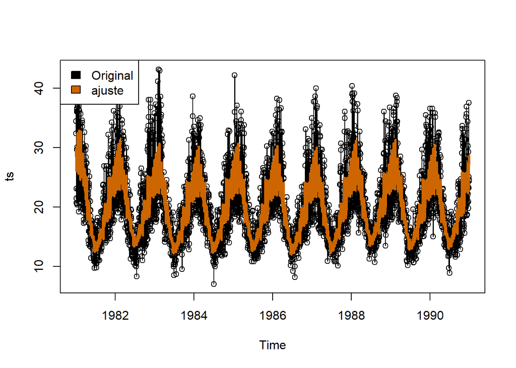

```r
# Grafico de la serie de tiempo
plot(ts, type = "o")
# Ajuste de la regresion
lines(fitted(reg), col = "#CD6600", lwd = 3)
# Etiquetas
legend(x = "topleft", c("Original", "ajuste"), fill = c("black", "#CD6600"))
```

De lo anterior, podemos obtener la tendencia y el ciclo estacional de la serie de tiempo.

- Para obtener la tendencia debemos excluir el ciclo estacional de la serie de tiempo ($M$), lo cual haremos de la siguiente manera:

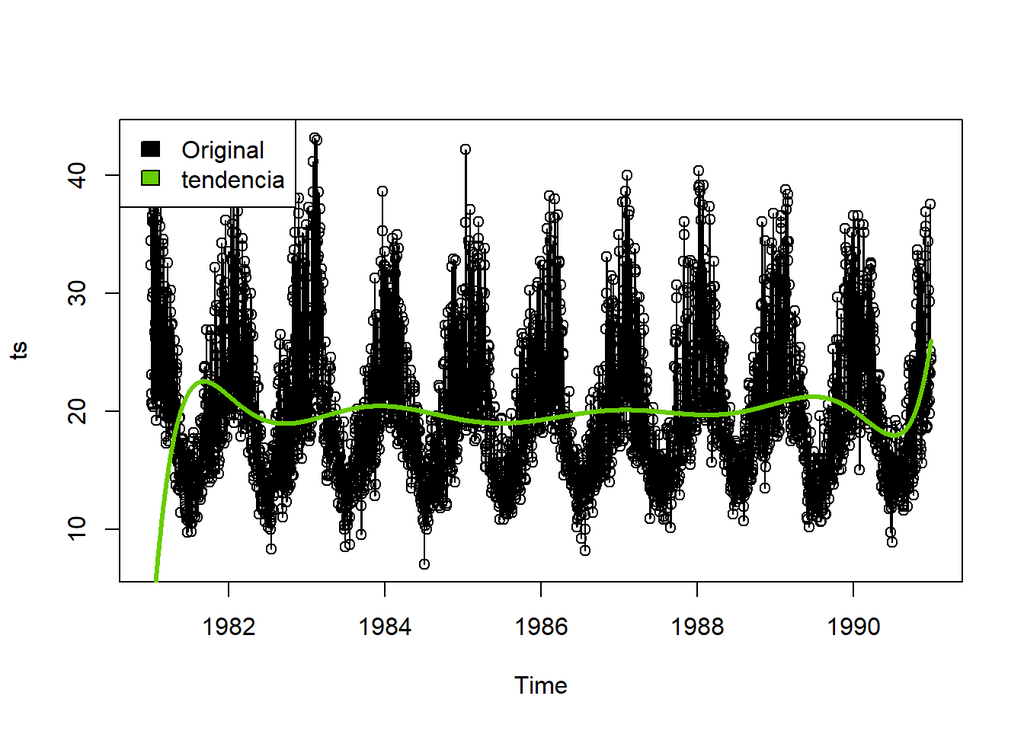

```r
# Regresion sin ciclo (es decir, componente de la tendencia)
reg_tend <- lm(ts ~ 0+ t + t2+ t3+ t4+ t5 + t6 + t7 + t8 + t9, na.action=NULL)

# Graficamos los resultados
plot(ts, type = "o")
# Grafico de la tendencia
lines(fitted(reg_tend), col = "#66CD00", lwd = 3)
# Etiquetas
legend(x = "topleft", c("Original", "tendencia"), fill = c("black", "#66CD00"))
```

notamos a partir del ajuste que, en efecto, la tendencia parece ser constante como se había mencionado previamente.

- Para obtener el ciclo estacional anularemos todas las variables de tiempo que se utilizaron en la regresión lineal y así quedarnos solo con el ciclo.

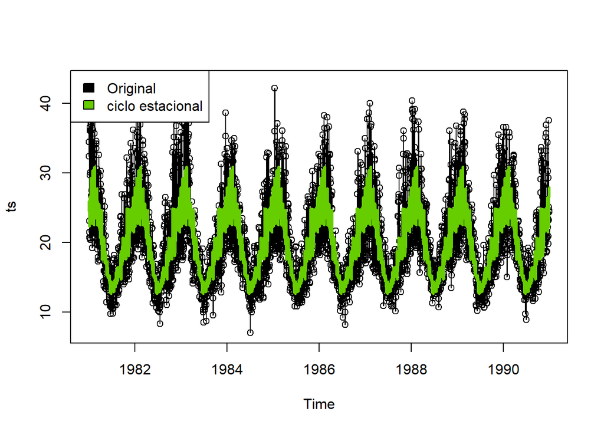

```r
# Ajuste de la regresion
reg_cicl <- lm(ts ~ 0 + M, na.action = NULL)

# Graficamos los resultados
plot(ts, type = "o")
lines(fitted(reg_cicl), col = "#66CD00", lwd = 3)
legend(x = "topleft", c("Original", "ciclo estacional"), fill = c("black", "#66CD00"))
```

vemos que el ajuste del ciclo es bastante bueno y capta el patrón.

A partir del ``ACF` y el `PACF` podemos determinar que el modelo adecuado para esta serie de tiempo podría ser un $AR$. Antes de realizar el ajuste, debemos ver si los datos cumplen con los supuestos de normalidad, varianza constante, independencia y estacionariedad, y partir de esto obtener el mejor modelo.

## Análisis de los supuestos

### Normalidad

Observamos el $p-value$ resultante de la prueba de Anderson-Darling y la respectiva gráfica `qqplot`:

```r
ad.test(ts)
```

```
##
##  Anderson-Darling normality test
##
## data:  ts
## A = 64.429, p-value < 2.2e-16
```

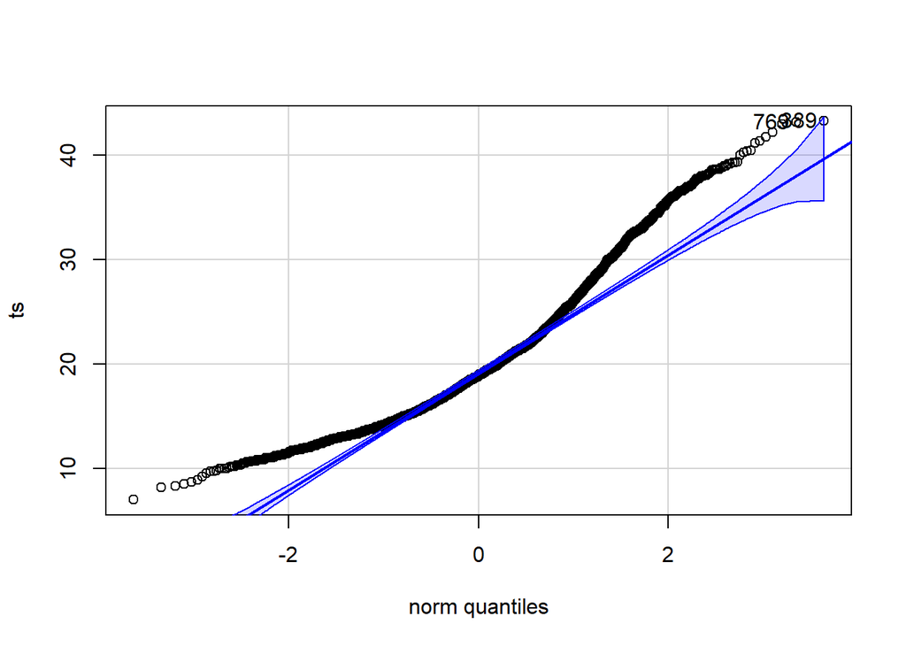

```
## [1] 389 769
```

```r
qqPlot(ts)
```

Con la prueba de normalidad anterior, tenemos un $p-value<2.2 e^{-16}$ por lo que no tenemos suficiente evidencia para aceptar $H_0$, de tal manera asumimos que no se cumple el supuesto de la normalidad.

### Varianza constante

Procedemos a realizar dos pruebas de hipótesis para verificar si la varianza es contante o no:

```r
# Definimos las variables para realizar las pruebas
Y <- as.numeric(ts)
X <- 1:length(ts)

# Test
bptest(Y~X)
```

```
##
##  studentized Breusch-Pagan test
##
## data:  Y ~ X
## BP = 10.448, df = 1, p-value = 0.001228
```

```r
ncvTest(lm(Y~X))
```

```
## Non-constant Variance Score Test
## Variance formula: ~ fitted.values
## Chisquare = 13.61731, Df = 1, p = 0.00022411
```

En ambas pruebas obtenemos que $p-value<0.05$, con lo que podemos decir que no hay evidencia suficiente para aceptar $H_0$, por lo tanto asumimos plausible la hipótesis alternativa: la varianza no es constante.

### Independencia

Realizamos una prueba para la correlación de los datos para algunos valores específicos

```r
Box.test(ts)
```

```
##
##  Box-Pierce test
##
## data:  ts
## X-squared = 1893.1, df = 1, p-value < 2.2e-16
```

```r
Box.test(ts,lag=1*365)
```

```
##
##  Box-Pierce test
##
## data:  ts
## X-squared = 139076, df = 365, p-value < 2.2e-16
```

```r
Box.test(ts,lag=2*365)
```

```
##
##  Box-Pierce test
##
## data:  ts
## X-squared = 246073, df = 730, p-value < 2.2e-16
```

```r
Box.test(ts,lag=3*365)
```

```
##
##  Box-Pierce test
##
## data:  ts
## X-squared = 328349, df = 1095, p-value < 2.2e-16
```

```r
Box.test(ts,lag=4*365)
```

```
##
##  Box-Pierce test
##
## data:  ts
## X-squared = 391079, df = 1460, p-value < 2.2e-16
```

```r
Box.test(ts,lag=5*365)
```

```
##
##  Box-Pierce test
##
## data:  ts
## X-squared = 438236, df = 1825, p-value < 2.2e-16
```

De acuerdo con las diferentes pruebas, ningún *lag* pasa la prueba de independencia.

### Estacionariedad

```r
adf.test(ts)
```

```
##
##  Augmented Dickey-Fuller Test
##
## data:  ts
## Dickey-Fuller = -5.4075, Lag order = 15, p-value = 0.01
## alternative hypothesis: stationary
```

Con la prueba de Dickey Fuller obtuvimos un $p-value = 0.01$, por lo que no hay evidencia suficiente para aceptar $H_0$, de modo que asumimos plausible decir que la serie de tiempo es estacionaria.

Con base en los resultados de los supuestos, se puede ver que es necesario aplicarle una transformación a los datos. Proponemos trabajar con un ciclo de 12 en lugar de uno de 365. De tal manera, procedemos de la siguiente manera:

```r
# variables auxiliares
Yt <- c()
t <- c()
u <- c()

# Realizamos propiamente el cambio del ciclo
for(i in 1:121){

  for(j in 1:30){
    t[j]= ts[(i-1)*30 + j]
  }

  Yt[i] = max(t)
}

for(j in 1:20){
  u[j]= ts[(121)*30 + j]
}

Yt[122] <- max(u)

ts_2 <- ts(Yt, start = c(1981,1), end = c(1991,2), frequency = 12)
```

Con esto tenemos una serie de tiempo con observaciones mensuales por lo que tendríamos un período de 12 con el que será más fácil trabajar.

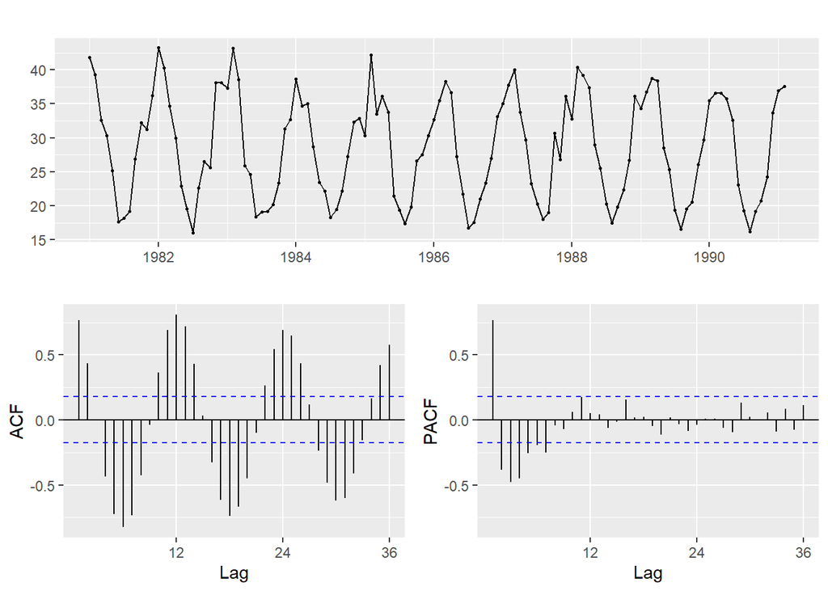

```r
# Observamos la gráfica de los datos transformados
ggtsdisplay(ts_2)
```

Después, utilizamos la función `auto.arima()` para ver un posible modelo que se acople a nuestros datos:

```r
auto.arima(ts_2)
```

```
## Series: ts_2
## ARIMA(0,0,0)(0,1,1)[12]
##
## Coefficients:
##          sma1
##       -0.4470
## s.e.   0.0844
##
## sigma^2 = 9.465:  log likelihood = -280.54
## AIC=565.07   AICc=565.18   BIC=570.47
```

Con lo anterior, probamos el siguiente modelo

```r
mod1 <- arima(ts_2, order=c(p=0, d=0, q=0),
              seasonal=list(order=c(P=0, D=1, Q=1), period = 12))

mod1
```

```
##
## Call:
## arima(x = ts_2, order = c(p = 0, d = 0, q = 0), seasonal = list(order = c(P = 0,
##     D = 1, Q = 1), period = 12))
##
## Coefficients:
##          sma1
##       -0.4470
## s.e.   0.0844
##
## sigma^2 estimated as 9.379:  log likelihood = -280.54,  aic = 565.07
```

## Supuestos del modelo ARIMA 1

Ahora que tenemos el modelo, comprobaremos que se cumplen los siguientes supuestos:

## Normalidad

```r
# Prueba de hipotesis
ad.test(mod1$residuals)
```

```
##
##  Anderson-Darling normality test
##
## data:  mod1$residuals
## A = 1.0985, p-value = 0.006774
```

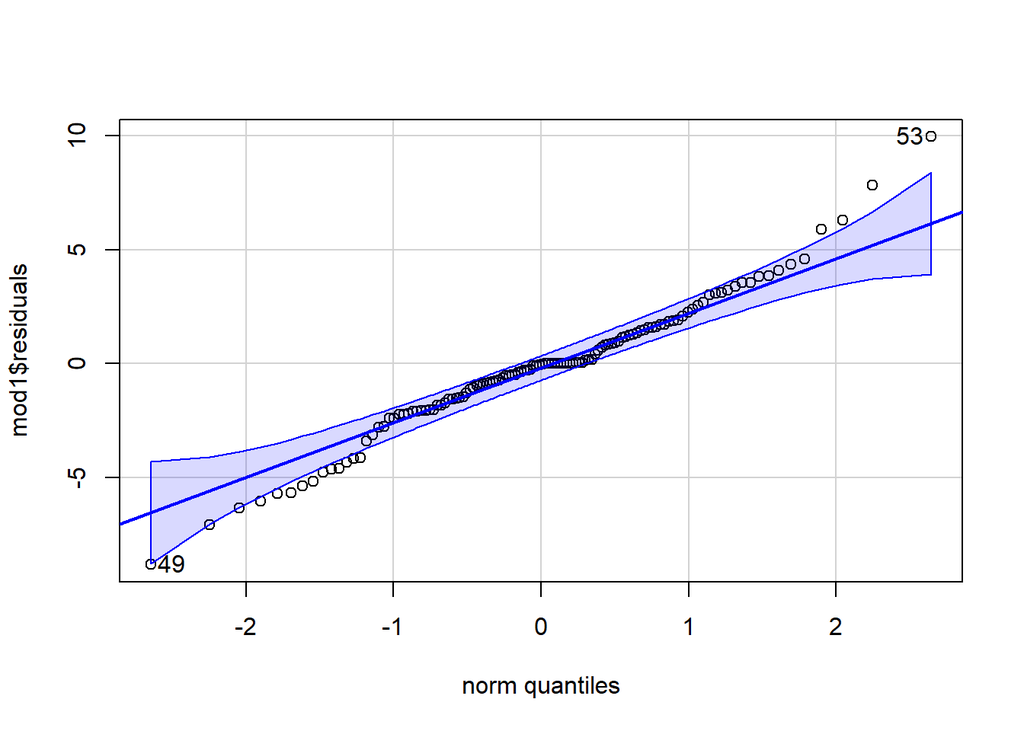

```
## [1] 53 49
```

```r
# Grafico qqplot
qqPlot(mod1$residuals)
```

Con esto podemos ver que este modelo tampoco cumple con el supuesto de normalidad.

### Varianza constante

```r
# Variables auxiliares
Y <- as.numeric(mod1$residuals)
X <- 1:length(mod1$residuals)

# Test
bptest(Y ~ X)
```

```
##
##  studentized Breusch-Pagan test
##
## data:  Y ~ X
## BP = 0.80011, df = 1, p-value = 0.3711
```

```r
ncvTest(lm(Y~X))
```

```
## Non-constant Variance Score Test
## Variance formula: ~ fitted.values
## Chisquare = 1.319565, Df = 1, p = 0.25067
```

Con esto vemos que el modelo SI cumple con el supuesto de varianza constante.

### Independencia

```r
Box.test(mod1$residuals)
```

```
##
##  Box-Pierce test
##
## data:  mod1$residuals
## X-squared = 0.41796, df = 1, p-value = 0.518
```

```r
Box.test(mod1$residuals,lag=1*12)
```

```
##
##  Box-Pierce test
##
## data:  mod1$residuals
## X-squared = 19.925, df = 12, p-value = 0.06851
```

```r
Box.test(mod1$residuals,lag=2*12)
```

```
##
##  Box-Pierce test
##
## data:  mod1$residuals
## X-squared = 42.401, df = 24, p-value = 0.01163
```

```r
Box.test(mod1$residuals,lag=3*12)
```

```
##
##  Box-Pierce test
##
## data:  mod1$residuals
## X-squared = 55.575, df = 36, p-value = 0.01963
```

```r
Box.test(mod1$residuals,lag=4*12)
```

```
##
##  Box-Pierce test
##
## data:  mod1$residuals
## X-squared = 64.983, df = 48, p-value = 0.05164
```

```r
Box.test(mod1$residuals,lag=5*12)
```

```
##
##  Box-Pierce test
##
## data:  mod1$residuals
## X-squared = 72.051, df = 60, p-value = 0.137
```

Podemos ver que para lag 24 y 36 no se cumple con la independencia, sin embargo, para los demás si se cumple. De esto podemos concluir que habría que hacer algún ajuste al modelo puesto que este supueto tampoco se está cumpliendo.

### Estacionariedad

```r
adf.test(mod1$residuals)
```

```
##
##  Augmented Dickey-Fuller Test
##
## data:  mod1$residuals
## Dickey-Fuller = -4.7798, Lag order = 4, p-value = 0.01
## alternative hypothesis: stationary
```

Por último, este modelo si cumple con el supuesto de estacionariedad.

Ajustaremos un nuevo modelo, para poder modelar mejor la dependencia.

## Supuestos del modelo ARIMA 2

```r
mod2 <- arima(ts_2, order = c(p=0, d=0, q=0),
              seasonal=list(order=c(P=1, D=1, Q=1), period = 12))

mod2
```

```
##
## Call:
## arima(x = ts_2, order = c(p = 0, d = 0, q = 0), seasonal = list(order = c(P = 1,
##     D = 1, Q = 1), period = 12))
##
## Coefficients:
##          sar1     sma1
##       -0.1783  -0.2993
## s.e.   0.2125   0.2104
##
## sigma^2 estimated as 9.314:  log likelihood = -280.2,  aic = 566.4
```

Ahora que tenemos el modelo, comprobaremos que se cumplen los siguientes supuestos.

### Normalidad

```r
ad.test(mod2$residuals)
```

```
##
##  Anderson-Darling normality test
##
## data:  mod2$residuals
## A = 1.0483, p-value = 0.009021
```

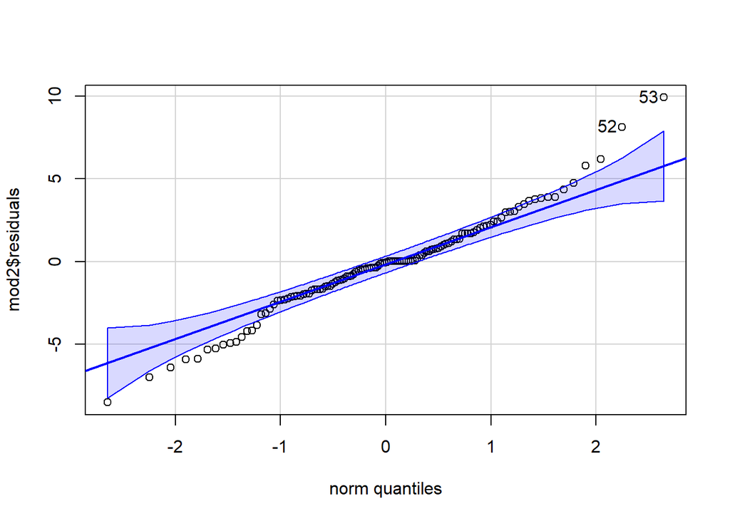

```
## [1] 53 52
```

```r
qqPlot(mod2$residuals)
```

Con estas pruebas podemos ver que ningún modelo trabajado, hasta ahora, cumple con normalidad.

### Varianza constante

```r
# Variables auxiliares
Y <- as.numeric(mod2$residuals)
X <- 1:length(mod2$residuals)

# Test
bptest(Y ~ X)
```

```
##
##  studentized Breusch-Pagan test
##
## data:  Y ~ X
## BP = 0.73848, df = 1, p-value = 0.3901
```

```r
ncvTest(lm(Y~X))
```

```
## Non-constant Variance Score Test
## Variance formula: ~ fitted.values
## Chisquare = 1.217163, Df = 1, p = 0.26992
```

Es plausible asumir que el modelo posee varianza constante.

### Independencia

```r
Box.test(mod2$residuals)
```

```
##
##  Box-Pierce test
##
## data:  mod2$residuals
## X-squared = 0.55036, df = 1, p-value = 0.4582
```

```r
Box.test(mod2$residuals,lag=1*12)
```

```
##
##  Box-Pierce test
##
## data:  mod2$residuals
## X-squared = 17.722, df = 12, p-value = 0.1244
```

```r
Box.test(mod2$residuals,lag=2*12)
```

```
##
##  Box-Pierce test
##
## data:  mod2$residuals
## X-squared = 35.942, df = 24, p-value = 0.0556
```

```r
Box.test(mod2$residuals,lag=3*12)
```

```
##
##  Box-Pierce test
##
## data:  mod2$residuals
## X-squared = 47.556, df = 36, p-value = 0.0942
```

```r
Box.test(mod2$residuals,lag=4*12)
```

```
##
##  Box-Pierce test
##
## data:  mod2$residuals
## X-squared = 55.581, df = 48, p-value = 0.2108
```

```r
Box.test(mod2$residuals,lag=5*12)
```

```
##
##  Box-Pierce test
##
## data:  mod2$residuals
## X-squared = 63.029, df = 60, p-value = 0.3697
```

Notamos que, ahora, con el ajuste del segundo modelo el supuesto de la independencia parece estar cumpliéndose. De manera general podemos emplear la prueba *Ljung-Box* donde:

- $H_{0}$: Los datos se distribuyen de manera independiente.
- - $H_{1}$: Los datos NO se distribuyen de manera independiente.

La cual no dependerá de los *lags*, como lo vimos antes, y en su lugar trabajaremos en general con los datos.

```r
Box.test(mod2$residuals, type = "Ljung-Box")
```

```
##
##  Box-Ljung test
##
## data:  mod2$residuals
## X-squared = 0.56401, df = 1, p-value = 0.4527
```

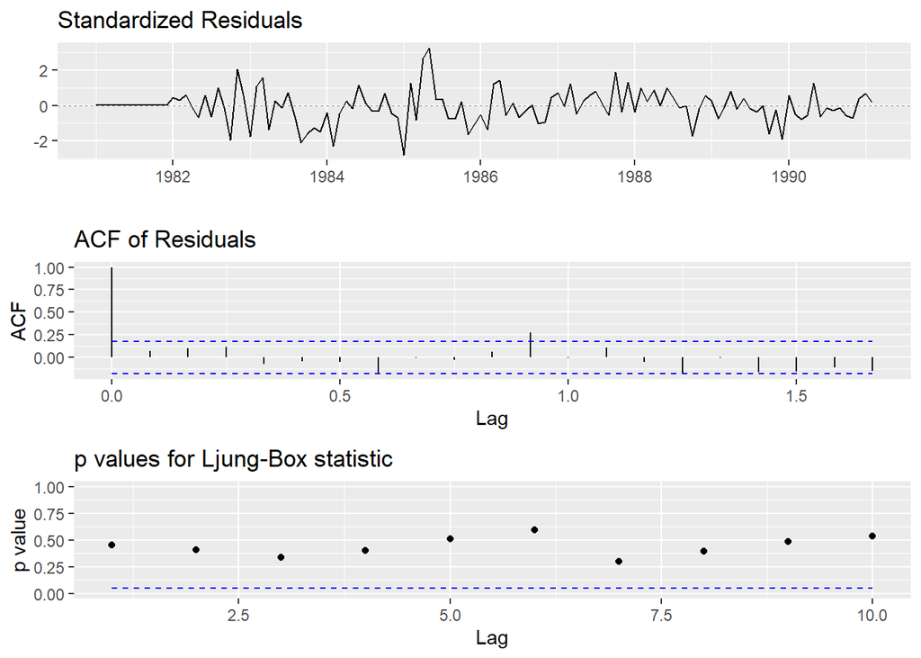

```r
# nos interesan p-value > alpha
ggtsdiag(mod2)
```

Comprobamos entonces, bajo cierto nivel de confianza, que los datos se distribuyen aleatoriamente.

### Estacionariedad

```r
adf.test(mod2$residuals)
```

```
##
##  Augmented Dickey-Fuller Test
##
## data:  mod2$residuals
## Dickey-Fuller = -4.7413, Lag order = 4, p-value = 0.01
## alternative hypothesis: stationary
```

Por último, tenemos que se cumple la estacionariedad.

Con este modelo se realiza un buen ajuste, ya que cumple con todos los supuestos, a excepción de la normalidad. Podemos no ser tan estrictos y optar por quedarnos con el modelo `mod2`.

## Prónostico

### Utilizando Holt-Winters

Después, realizamos la predicción a un año con los intervalos de predicción visibles:

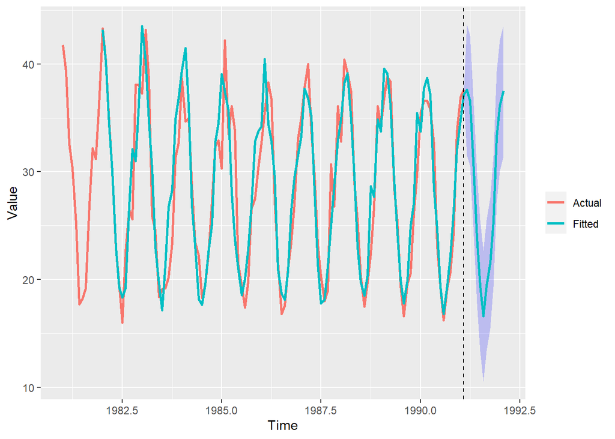

```r
HWplot3(ts_2, n.ahead = 12)
```

### Utilizando el modelo ARIMA 2

En este caso realizaremos, de igual manera, el pronóstico a un año, pero ahora utilizando el modelo ARIMA almacenado en `mod2`:

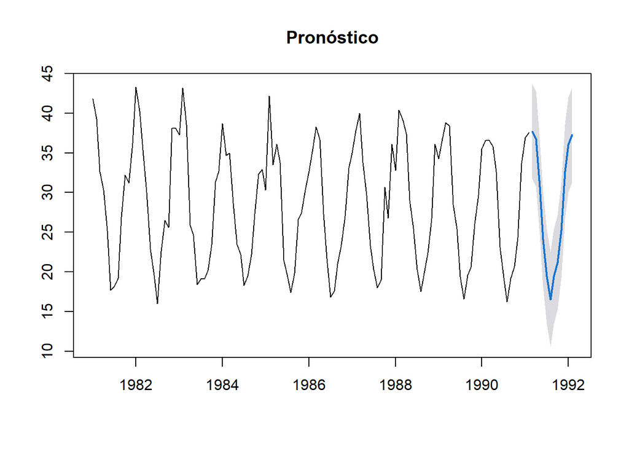

```r
# libreria necesaria
 library(forecast)

pronostico <- forecast(mod2, 12, level=95)
plot(pronostico, main="Pronóstico")
```

vemos que en ambos casos los pronósticos parecen ser muy similares:

```r
# Ajustamos el modelo holt-winters
holt <- HoltWinters(ts_2)

# Realizamos el pronostico con dicho modelo
pronostico_holt <- predict(holt,  n.ahead=12, prediction.interval=T,  level=0.95)

# Creamos un dataframe con las predicciones de ambos modelos
pred <- data.frame(
  "Holt"=pronostico_holt[1:12],
  "Arima"=as.data.frame(pronostico)[,1])

pred
```

```
##        Holt    Arima
## 1  37.62352 37.70461
## 2  36.56116 36.77072
## 3  30.97381 30.72564
## 4  23.86977 24.09709
## 5  19.42535 19.44033
## 6  16.59178 16.53781
## 7  19.44987 19.40916
## 8  21.52561 21.18340
## 9  25.38842 25.26001
## 10 33.22490 32.65862
## 11 36.17202 36.01503
## 12 37.53803 37.26876
```

o de manera gráfica mediante un diagrama de líneas referente a las predicciones con ambos modelos:

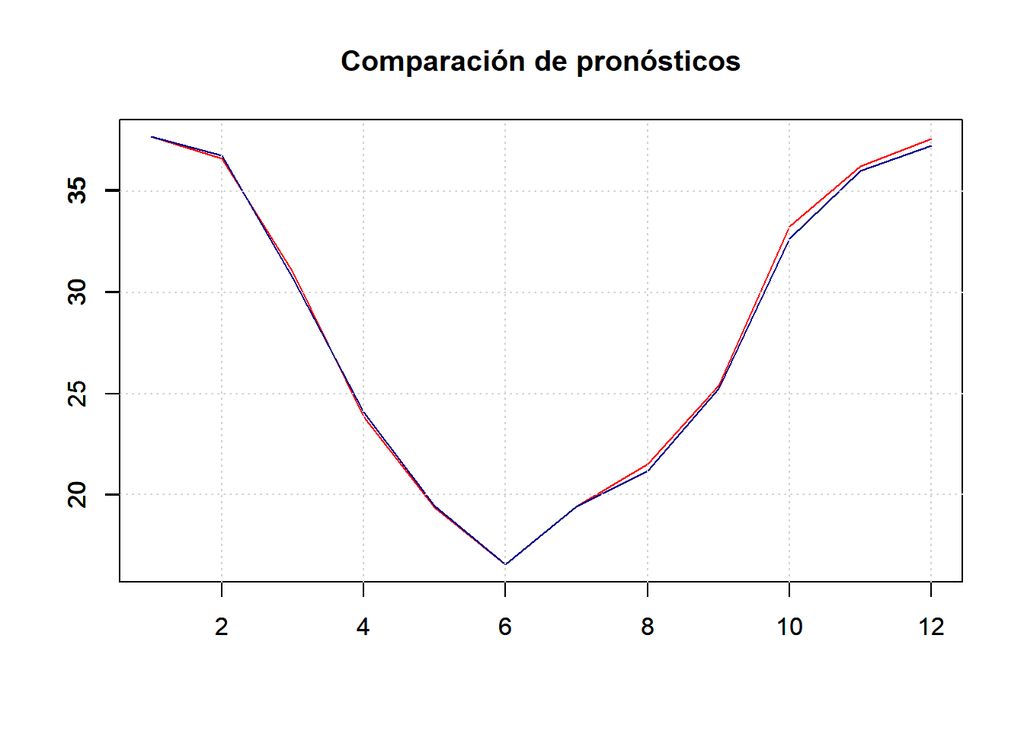

```r
plot(x=1:12, pred$Holt, type="l", col = "red", ylab=" ",
     xlab=" ", main="Comparación de pronósticos")
par(new=TRUE)
plot(x=1:12, pred$Arima, type="l", col = "darkblue", ylab=" ",
     xlab=" ")
grid()
```

Tenemos entonces que las predicciones entre el modelo ARIMA y el modelo Holt-Winters han sido muy similares.